# 51 Exploratory Data Analysis - REMOVED clones

Anders Sundelin

2023-03-18

## Exploring how much duplicates that are removed by teams

```r
source("ingest_data.R")
levels(data$repo)
```

```
## [1] "IntTest" "Jupiter" "Mars"    "Mercury" "Neptune" "Saturn"  "Uranus"
## [8] "Venus"
```

```r
levels(data$committerteam)
```

```
##  [1] "Arch"    "Blue"    "Brown"   "Green"   "Orange"  "Pink"    "Red"
##  [8] "UI"      "Unknown" "Violet"  "Yellow"
```

```r
levels(data$authorteam)
```

```
##  [1] "Arch"    "Blue"    "Brown"   "Green"   "Orange"  "Pink"    "Red"
##  [8] "UI"      "Unknown" "Violet"  "Yellow"
```

# Exploratory Data Analysis

We see that duplicates are rarely removed - the 95th percentile is 0, and the 99th is 3.

```r
data |> summarize(min(REMOVED), median(REMOVED), q95(REMOVED), q99(REMOVED), max(REMOVED))
```

```
##   min(REMOVED) median(REMOVED) q95(REMOVED) q99(REMOVED) max(REMOVED)
## 1            0               0            0            3          112
```

But there are still changes when teams remove duplicates—some teams more than others. And some removals are large - even though most are small.

```r
data |> filter(REMOVED > 0) |> group_by(committerteam, REMOVED) |> tally()
```

```
## # A tibble: 122 × 3
## # Groups:   committerteam [11]
##    committerteam REMOVED     n
##    <fct>           <int> <int>
##  1 Arch                1    45
##  2 Arch                2    25
##  3 Arch                3     5
##  4 Arch                4    12
##  5 Arch                5     4
##  6 Arch                6     6
##  7 Arch                7     2
##  8 Arch                8     1
##  9 Arch                9     2
## 10 Arch               11     1
## # ℹ 112 more rows
```

For the most part, teams do not remove duplicates. If they do, they often remove few (single-digits).

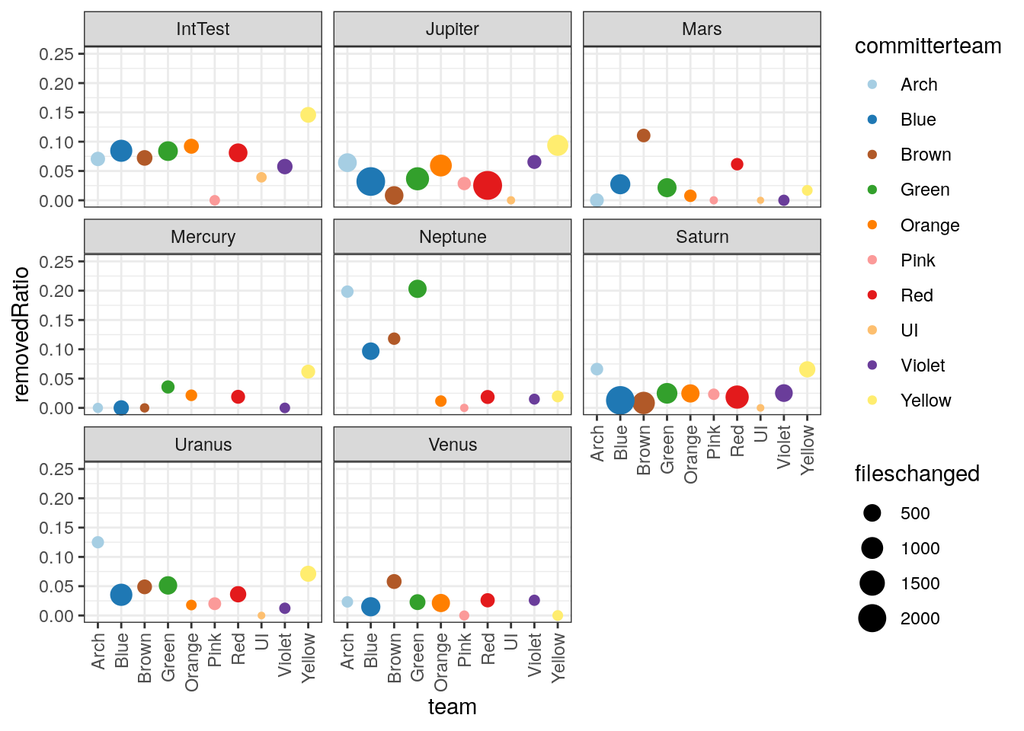

```r
changesPerRepoAndTeam <- data |> group_by(repo, committerteam) |> summarise(fileschanged=n())
zerosPerRepoAndTeam <- data |> filter(REMOVED == 0) |> group_by(repo, committerteam) |> summarise(zeros=n())
zeros_ratio <- merge(changesPerRepoAndTeam, zerosPerRepoAndTeam) |> mutate(removedRatio = 1-(zeros/fileschanged)) |> arrange(removedRatio)

(p <- zeros_ratio |> filter(committerteam != "Unknown") |> ggplot(aes(x=committerteam, y=removedRatio, color=committerteam, size=fileschanged)) + geom_point() + facet_wrap(~ repo) + xlab("team") + scale_color_manual(values=COLOR_BY_TEAM) + theme_bw() + scale_y_continuous(limits=c(0,0.25)) + theme(axis.text.x = element_text(angle = 90, vjust = 0.5, hjust=1))
)
```

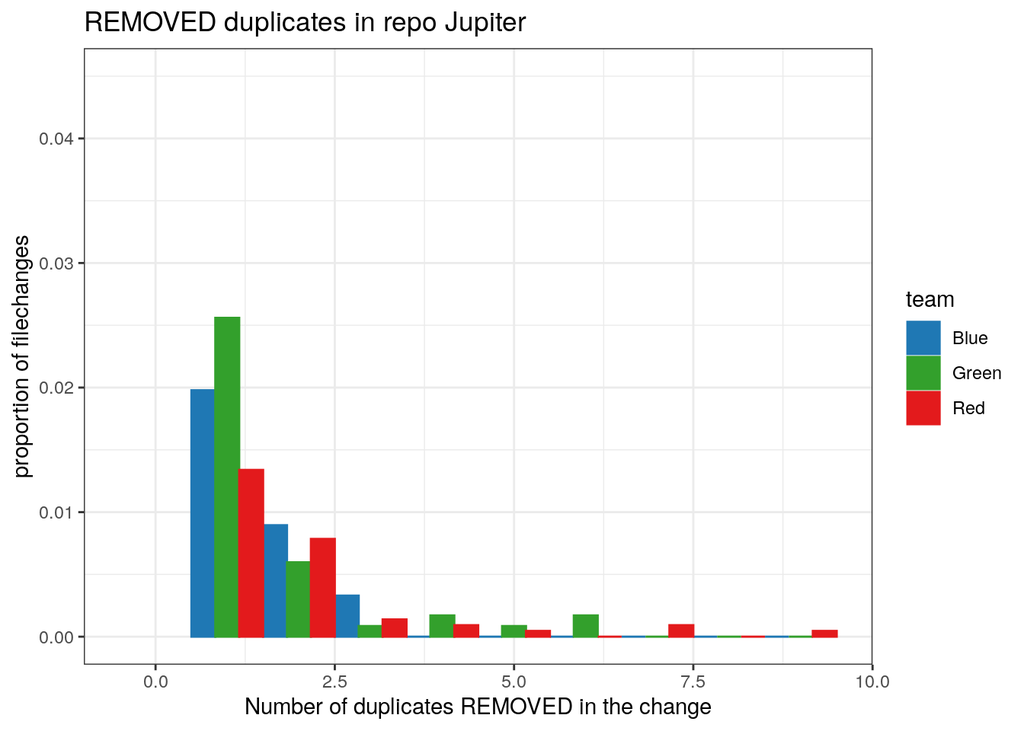

```r
plot_REMOVED_issues_in_repo <- function(aRepo, team_selector) {
  data |> filter(repo == aRepo, team_selector(committerteam)) |> mutate(team = committerteam) |> group_by(team) |> ggplot(aes(x=REMOVED, color=team, fill=team)) + geom_histogram(aes(y=after_stat(density)), position = "dodge", binwidth = 1) + ggtitle(paste("REMOVED duplicates in repo", aRepo)) + scale_fill_manual(name="team", values=teamcolors) + scale_colour_manual(name="team", values=teamcolors) + ylab("proportion of filechanges") + xlab("Number of duplicates REMOVED in the change") + ylim(0,0.1)
}
three_teams <- function(x) x %in% c(RED, BLUE, GREEN)

plot_REMOVED_issues_in_repo(JUPITER, three_teams) + theme_bw() + ylim(0,0.045)
```

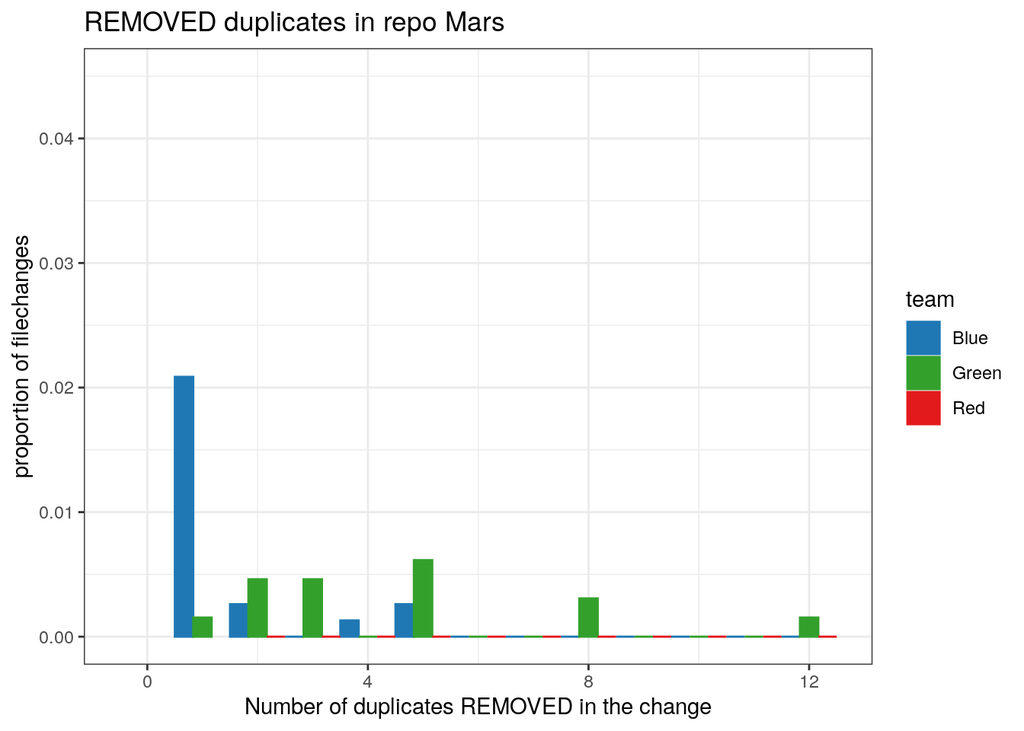

```r
plot_REMOVED_issues_in_repo(MARS, three_teams) + theme_bw() + ylim(0,0.045)
```

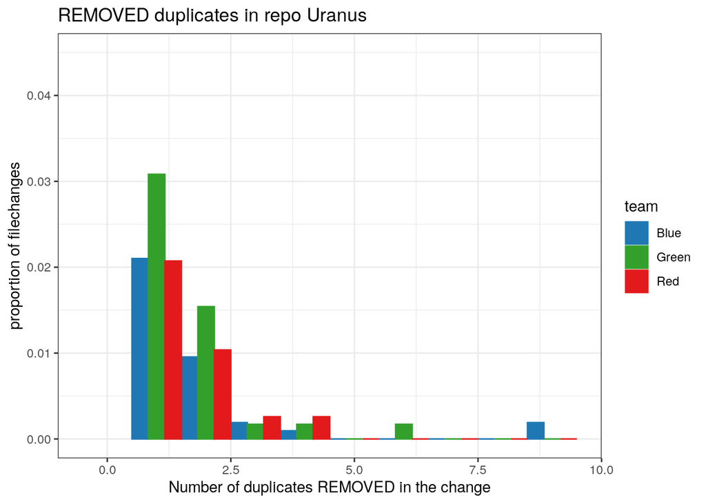

```r
plot_REMOVED_issues_in_repo(URANUS, three_teams) + theme_bw() + ylim(0,0.045)
```

```r
# quantile type 3 to avoid having interpolation of the observations
repo_committerteam <- data |> group_by(repo, committerteam) |> summarize(q95=quantile(REMOVED, 0.95, type=3),
                                                                         q99=quantile(REMOVED, 0.99, type=3),
                                                                         max=max(REMOVED),
                                                                         files=n(),
                                                                         mean_added=mean(ADD),
                                                                         median_added=median(ADD),
                                                                         mean_removed=mean(DEL),
                                                                         median_removed=median(DEL)) |> mutate(team=committerteam)
```

### 95th percentile

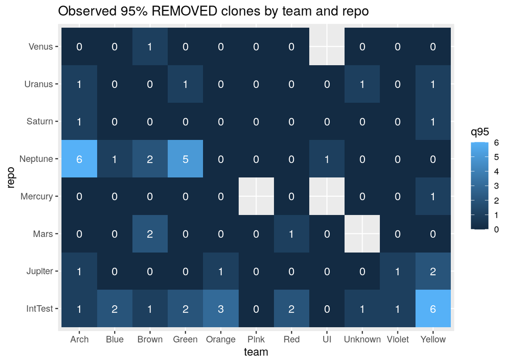

```r
repo_committerteam |> ggplot(aes(x=team, y=repo)) +
    geom_tile(aes(fill=q95)) +
    geom_text(aes(label=round(q95, 0)), color="white") +
    xlab("team") + ylab("repo") +
    ggtitle(paste("Observed 95% REMOVED clones by team and repo"))
```

The 95% quantile plots show that for many repos, and many teams in those repos, in 19 out of 20 file changes, no duplicates were removed. The outlier is IntTest, where many teams have removed single-digit duplicates. In the Neptune repository, we also can see some more duplicate removals by the Architect and Green teams.

### 99th percentile

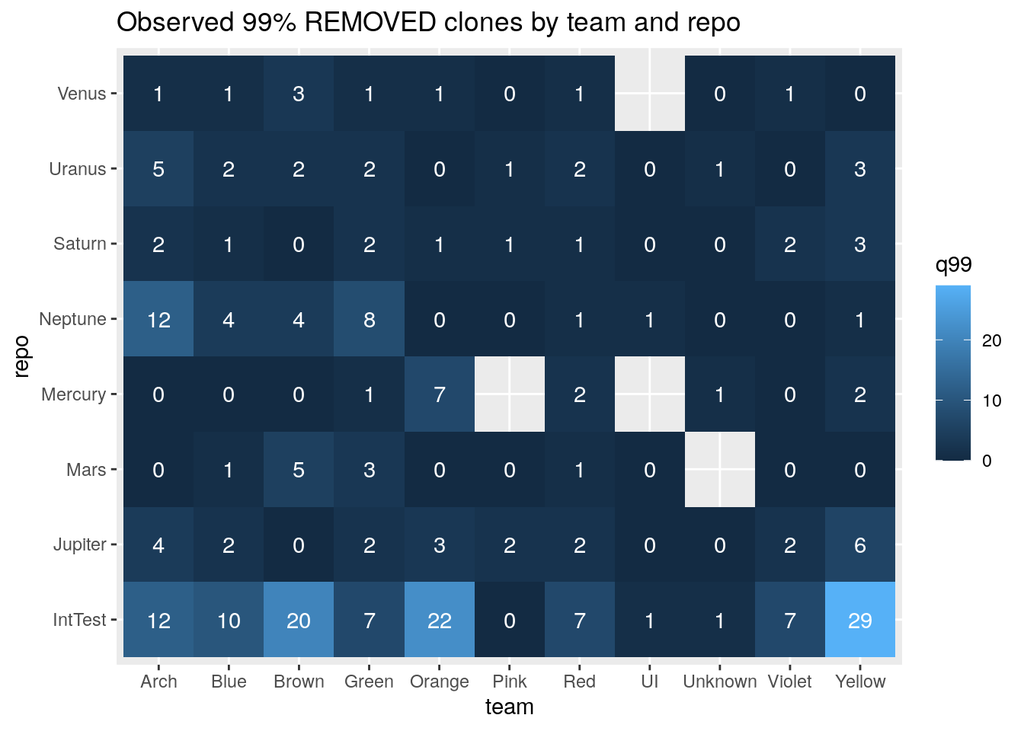

```r
repo_committerteam |> ggplot(aes(x=team, y=repo)) +
    geom_tile(aes(fill=q99)) +
    geom_text(aes(label=round(q99, 0)), color="white") +
    xlab("team") + ylab("repo") +
    ggtitle(paste("Observed 99% REMOVED clones by team and repo"))
```

The pattern repeats for the 99% quantile. More duplicates are removed in IntTest, and Jupiter is now also starting to show some removals. In the Neptune repo, however, it is still the Architect and Green teams that remove duplicates, with Blue and Brown trailing.

### Maximum removed duplicates

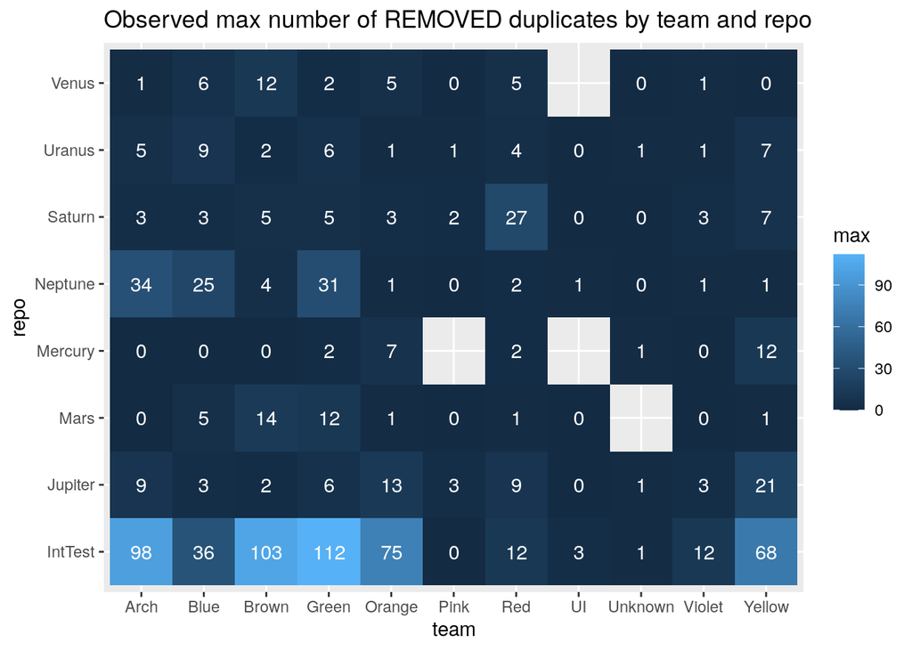

```r
repo_committerteam|> ggplot(aes(x=team, y=repo)) +
    geom_tile(aes(fill=max)) +
    geom_text(aes(label=round(max, 0)), color="white") +
    xlab("team") + ylab("repo") +
    ggtitle(paste("Observed max number of REMOVED duplicates by team and repo"))
```

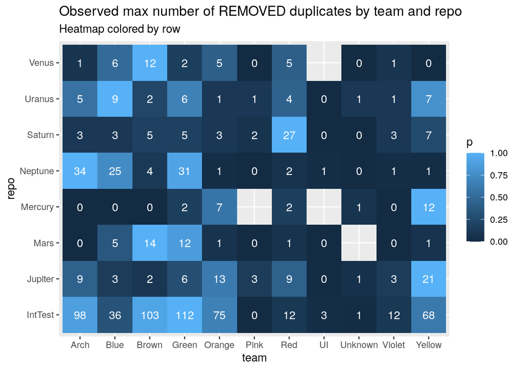

```r
repo_committerteam_summary <- repo_committerteam |> mutate(max=replace_na(max, 0)) |> group_by(repo) |> summarize(mx=max(max), mn=min(max))
(p <- repo_committerteam |> inner_join(repo_committerteam_summary) |> mutate(p=(max - mn)/(mx-mn)) |>
  ggplot(aes(x=team, y=repo)) +
    geom_tile(aes(fill=p)) +
    geom_text(aes(label=round(max, 0)), color="white") +
    xlab("team") + ylab("repo") +
    ggtitle("Observed max number of REMOVED duplicates by team and repo", "Heatmap colored by row")
)
```